# BN_Restoration

Patricia Varela

July 24, 2017

## Description

This is an overall description of the BN model used for the workshop synthesis.

Includes: * Nodes description * BN Model’s attributes * Training BN * Definition of CPTs * Applied R code using manual and fitted relationships of collected data.

```r
#Figure Fireworks
```

[output not shown]

The Proposed Model - The Test Model

- Conditional probability tables represent the cause and effect relationship of the model’s variables
- Qualitative classification of their attributes.

```r
library(readr)
NodeTypes = read.csv("~/NCEAS/Model/NodeClasses.csv")
NodeTypesTB = data.frame(NodeTypes)
print(NodeTypesTB)
```

```
##                  Node                 Type              Classes
## 1 Habitat Restoration Restoration Activity        "PRE", "POST"
## 2     Water Treatment Restoration Activity        "PRE", "POST"
## 3            Salinity                  PDF "LOW", "MOD", "HIGH"
## 4         Chlorophyll                  PDF "LOW", "MOD", "HIGH"
```

# Training CPTs

Data Fomat: classified observations

```r
#Load Salinity data
Salin = read.csv("~/NCEAS/Model/SalData.csv")
Salinity = data.frame(Salin)
#Load Chlorophyll data
Cholorop = read.csv("~/NCEAS/Model/ChlData.csv")
Chlorophyll = data.frame(Cholorop)
print(head(Salinity))
```

```
##     HR   WT Sal
## 1 POST POST LOW
## 2 POST POST LOW
## 3 POST POST LOW
## 4 POST POST MOD
## 5 POST POST MOD
## 6 POST POST MOD
```

```r
print(head(Chlorophyll))
```

```
##     HR   WT Sal  Chl
## 1 POST POST LOW  LOW
## 2 POST POST LOW  LOW
## 3 POST POST LOW HIGH
## 4 POST POST LOW  LOW
## 5 POST POST LOW  LOW
## 6 POST POST LOW  LOW
```

# Training CPTs

The training of the conditional probability tables is made by counting the number of observations that match each combination of the discrete variables influencing the child nodes “Salinity” and “Chlorophyll”.

# Salinity:

From the water quality data is necessary to extract the values depicted in the following “Key” table.

```r
#Load Salinity key
KeySalin = read.csv("~/NCEAS/Model/KeySal.csv")
KeySalinity = data.frame(KeySalin)
print(KeySalinity)
```

```
##   Num  X1  X2   X3   X4   X5   X6   X7   X8   X9  X10  X11  X12
## 1  HR PRE PRE  PRE  PRE  PRE  PRE POST POST POST POST POST POST
## 2  WT PRE PRE  PRE POST POST POST  PRE  PRE  PRE POST POST POST
## 3 Sal LOW MOD HIGH  LOW  MOD HIGH  LOW  MOD HIGH  LOW  MOD HIGH
```

# Chlorophyll:

Likewise, from the water quality data is necessary to extract the values depicted in the following “Key” table.

```r
#Load Clorophyll key
KeyChlor = read.csv("~/NCEAS/Model/KeyChl.csv")
KeyChlorophyll = data.frame(KeyChlor)
print(KeyChlorophyll)
```

```
##   Num  X1  X2   X3  X4  X5   X6   X7   X8   X9  X10  X11  X12  X13  X14
## 1  HR PRE PRE  PRE PRE PRE  PRE  PRE  PRE  PRE  PRE  PRE  PRE  PRE  PRE
## 2  WT PRE PRE  PRE PRE PRE  PRE  PRE  PRE  PRE POST POST POST POST POST
## 3 Sal LOW LOW  LOW MOD MOD  MOD HIGH HIGH HIGH  LOW  LOW  LOW  MOD  MOD
## 4 Chl LOW MOD HIGH LOW MOD HIGH  LOW  MOD HIGH  LOW  MOD HIGH  LOW  MOD
##    X15  X16  X17  X18  X19  X20  X21  X22  X23  X24  X25  X26  X27  X28
## 1  PRE  PRE  PRE  PRE POST POST POST POST POST POST POST POST POST POST
## 2 POST POST POST POST  PRE  PRE  PRE  PRE  PRE  PRE  PRE  PRE  PRE POST
## 3  MOD HIGH HIGH HIGH  LOW  LOW  LOW  MOD  MOD  MOD HIGH HIGH HIGH  LOW
## 4 HIGH  LOW  MOD HIGH  LOW  MOD HIGH  LOW  MOD HIGH  LOW  MOD HIGH  LOW
##    X29  X30  X31  X32  X33  X34  X35  X36
## 1 POST POST POST POST POST POST POST POST
## 2 POST POST POST POST POST POST POST POST
## 3  LOW  LOW  MOD  MOD  MOD HIGH HIGH HIGH
## 4  MOD HIGH  LOW  MOD HIGH  LOW  MOD HIGH
```

# Training CPTs

From the classified water quality data, it is possible to count the number of observations in each column of the key tables.

(See file “GetCPTs.xlsx”, pending to code)

```r
#Code training data to obtain CPTs
```

Get frequency of observations for all possible combinations.

# BN Modeling with manual definition of CPTs

```r
library(bnlearn)
```

```r
#Method 1: Manual definition of CPTs:
#Create marginal probability tables manually
cptHR <- matrix(c(1, 0), ncol = 2, dimnames = list(NULL, c("PRE", "POST")))
cptWT <- matrix(c(1, 0), ncol = 2, dimnames = list(NULL, c("PRE", "POST")))
cptSal <- (c(0.533, 0.289, 0.178, 0.667, 0.155, 0.178, 0.4, 0.422, 0.178, 0.533, 0.289, 0.178))
dim(cptSal) <- c(3, 2, 2)
dimnames(cptSal) <- list("Sal" = c("LOW", "MOD", "HIGH"), "HR" =  c("PRE", "POST"), "WT" = c("PRE", "POST"))
cptChl <- (c(0.542, 0.25, 0.208, 0.308, 0.538, 0.154, 0.286, 0, 0.714, 0.633, 0.267, 0.1, 0.429, 0.142, 0.429, 0.286, 0.428, 0.286, 0.444, 0.389, 0.167, 0.526, 0.316, 0.158, 0.375, 0.375, 0.25, 0.708, 0.25, 0.042, 0.231, 0.692, 0.077, 0.25, 0.375, 0.375))
dim(cptChl) <- c(3, 3, 2, 2)
dimnames(cptChl) <- list("Chl" = c("LOW", "MOD", "HIGH"), "Sal" = c("LOW", "MOD", "HIGH"), "HR" =  c("PRE", "POST"), "WT" = c("PRE", "POST"))
##Create Network
net = model2network("[HR][WT][Sal|HR:WT][Chl|HR:WT:Sal]")
plot(net)
```

```r
##Assign CPTs to Network
dfit = custom.fit(net, dist = list(HR = cptHR, WT = cptWT, Sal = cptSal, Chl = cptChl))
dfit
```

```
##
##   Bayesian network parameters
##
##   Parameters of node Chl (multinomial distribution)
##
## Conditional probability table:
##
## , , Sal = LOW, WT = PRE
##
##       HR
## Chl      PRE  POST
##   LOW  0.542 0.633
##   MOD  0.250 0.267
##   HIGH 0.208 0.100
##
## , , Sal = MOD, WT = PRE
##
##       HR
## Chl      PRE  POST
##   LOW  0.308 0.429
##   MOD  0.538 0.142
##   HIGH 0.154 0.429
##
## , , Sal = HIGH, WT = PRE
##
##       HR
## Chl      PRE  POST
##   LOW  0.286 0.286
##   MOD  0.000 0.428
##   HIGH 0.714 0.286
##
## , , Sal = LOW, WT = POST
##
##       HR
## Chl      PRE  POST
##   LOW  0.444 0.708
##   MOD  0.389 0.250
##   HIGH 0.167 0.042
##
## , , Sal = MOD, WT = POST
```

[output cut: 35 more lines]

```
## , , WT = POST
##
##       HR
## Sal      PRE  POST
##   LOW  0.400 0.533
##   MOD  0.422 0.289
##   HIGH 0.178 0.178
##
##
##   Parameters of node WT (multinomial distribution)
##
## Conditional probability table:
##
##  PRE POST
##    1    0
```

```r
#Get inferences
set.seed(1)
cpquery(dfit, event = (Chl=="LOW"), evidence= (HR=="PRE"))
```

```
## [1] 0.4339
```

# BN Modeling with automated definition of CPTs

- Use package to define CPTs:

```r
library(bnlearn)
library(readr)
##Load training data for Chlorophyll node
Cholorop = read.csv("~/NCEAS/Model/ChlData.csv")
Chlorophyll = data.frame(Cholorop)
TrainDataCh <- Chlorophyll
#Preparing the format of training data
HR<-as.factor(TrainDataCh$HR)
WT<-as.factor(TrainDataCh$WT)
Sal<-as.factor(TrainDataCh$Sal)
Chl<-as.factor(TrainDataCh$Chl)
bn_restor <-data.frame(HR, WT, Sal, Chl)
#Create Network
net = model2network("[HR][WT][Sal|HR:WT][Chl|HR:WT:Sal]")
plot(net)
```

```r
#Creating CPTs from data
fittedBN <- bn.fit(net, data=bn_restor)
print(fittedBN$Chl)
```

```
##
##   Parameters of node Chl (multinomial distribution)
##
## Conditional probability table:
##
## , , Sal = HIGH, WT = POST
##
##       HR
## Chl          POST        PRE
##   HIGH 0.37500000 0.25000000
##   LOW  0.25000000 0.37500000
##   MOD  0.37500000 0.37500000
##
## , , Sal = LOW, WT = POST
##
##       HR
## Chl          POST        PRE
##   HIGH 0.04166667 0.16666667
##   LOW  0.70833333 0.44444444
##   MOD  0.25000000 0.38888889
##
## , , Sal = MOD, WT = POST
##
##       HR
## Chl          POST        PRE
##   HIGH 0.07692308 0.15789474
##   LOW  0.23076923 0.52631579
##   MOD  0.69230769 0.31578947
##
## , , Sal = HIGH, WT = PRE
##
##       HR
## Chl          POST        PRE
##   HIGH 0.28571429 0.71428571
##   LOW  0.28571429 0.28571429
##   MOD  0.42857143 0.00000000
##
## , , Sal = LOW, WT = PRE
##
##       HR
## Chl          POST        PRE
##   HIGH 0.10000000 0.20833333
##   LOW  0.63333333 0.54166667
##   MOD  0.26666667 0.25000000
##
## , , Sal = MOD, WT = PRE
##
##       HR
## Chl          POST        PRE
##   HIGH 0.42857143 0.15384615
##   LOW  0.42857143 0.30769231
##   MOD  0.14285714 0.53846154
```

```r
#Get inferences
cpquery(fittedBN, event = (Chl=="LOW"), evidence= (HR=="PRE"))
```

```
## [1] 0.4372861
```

```r
#OR Get inferences fixing two parent nodes
cpquery(fittedBN, event = (Chl=="LOW"), evidence= (HR=="PRE" & WT=="PRE"))
```

```
## [1] 0.4319287
```

Playing with the initial conditions of restoration activities, the results returned by GeNIe’s software are:

```r
cpquery(dfit, event = (Chl=="LOW"), evidence= (HR=="PRE" & WT=="PRE"))
```

```
## [1] 0.4281
```

```r
cpquery(dfit, event = (Chl=="MOD"), evidence= (HR=="PRE" & WT=="PRE"))
```

```
## [1] 0.2911
```

```r
cpquery(dfit, event = (Chl=="HIGH"), evidence= (HR=="PRE" & WT=="PRE"))
```

```
## [1] 0.2819
```

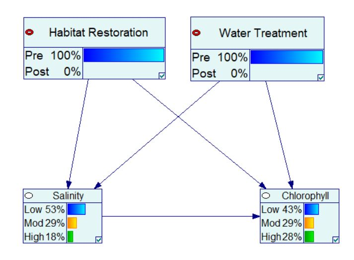

Before_HR, Before_WT

```r
#Create marginal probability tables manually
cptHR <- matrix(c(0, 1), ncol = 2, dimnames = list(NULL, c("PRE", "POST")))
cptWT <- matrix(c(0, 1), ncol = 2, dimnames = list(NULL, c("PRE", "POST")))
cptSal <- (c(0.533, 0.289, 0.178, 0.667, 0.155, 0.178, 0.4, 0.422, 0.178, 0.533, 0.289, 0.178))
dim(cptSal) <- c(3, 2, 2)
dimnames(cptSal) <- list("Sal" = c("LOW", "MOD", "HIGH"), "HR" =  c("PRE", "POST"), "WT" = c("PRE", "POST"))
cptChl <- (c(0.542, 0.25, 0.208, 0.308, 0.538, 0.154, 0.286, 0, 0.714, 0.633, 0.267, 0.1, 0.429, 0.142, 0.429, 0.286, 0.428, 0.286, 0.444, 0.389, 0.167, 0.526, 0.316, 0.158, 0.375, 0.375, 0.25, 0.708, 0.25, 0.042, 0.231, 0.692, 0.077, 0.25, 0.375, 0.375))
dim(cptChl) <- c(3, 3, 2, 2)
dimnames(cptChl) <- list("Chl" = c("LOW", "MOD", "HIGH"), "Sal" = c("LOW", "MOD", "HIGH"), "HR" =  c("PRE", "POST"), "WT" = c("PRE", "POST"))
##Create Network
net = model2network("[HR][WT][Sal|HR:WT][Chl|HR:WT:Sal]")
plot(net)
```

```r
##Assign CPTs to Network
dfit = custom.fit(net, dist = list(HR = cptHR, WT = cptWT, Sal = cptSal, Chl = cptChl))
dfit
```

```
##
##   Bayesian network parameters
##
##   Parameters of node Chl (multinomial distribution)
##
## Conditional probability table:
##
## , , Sal = LOW, WT = PRE
##
##       HR
## Chl      PRE  POST
##   LOW  0.542 0.633
##   MOD  0.250 0.267
##   HIGH 0.208 0.100
##
## , , Sal = MOD, WT = PRE
##
##       HR
## Chl      PRE  POST
##   LOW  0.308 0.429
##   MOD  0.538 0.142
##   HIGH 0.154 0.429
##
## , , Sal = HIGH, WT = PRE
##
##       HR
## Chl      PRE  POST
##   LOW  0.286 0.286
##   MOD  0.000 0.428
##   HIGH 0.714 0.286
##
## , , Sal = LOW, WT = POST
##
##       HR
## Chl      PRE  POST
##   LOW  0.444 0.708
##   MOD  0.389 0.250
##   HIGH 0.167 0.042
##
## , , Sal = MOD, WT = POST
```

[output cut: 35 more lines]

```
## , , WT = POST
##
##       HR
## Sal      PRE  POST
##   LOW  0.400 0.533
##   MOD  0.422 0.289
##   HIGH 0.178 0.178
##
##
##   Parameters of node WT (multinomial distribution)
##
## Conditional probability table:
##
##  PRE POST
##    0    1
```

```r
cpquery(dfit, event = (Chl=="LOW"), evidence= (HR=="POST" & WT=="POST"))
```

```
## [1] 0.494
```

```r
cpquery(dfit, event = (Chl=="MOD"), evidence= (HR=="POST" & WT=="POST"))
```

```
## [1] 0.4087
```

```r
cpquery(dfit, event = (Chl=="HIGH"), evidence= (HR=="POST" & WT=="POST"))
```

```
## [1] 0.1182
```

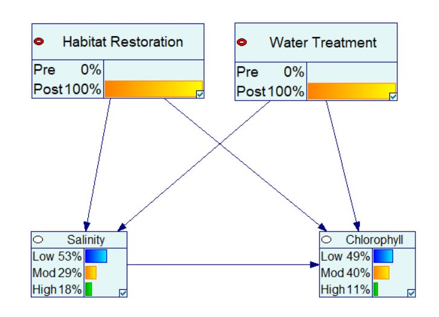

After_HR, After_WT

```r
#Create marginal probability tables manually
cptHR <- matrix(c(1, 0), ncol = 2, dimnames = list(NULL, c("PRE", "POST")))
cptWT <- matrix(c(0, 1), ncol = 2, dimnames = list(NULL, c("PRE", "POST")))
cptSal <- (c(0.533, 0.289, 0.178, 0.667, 0.155, 0.178, 0.4, 0.422, 0.178, 0.533, 0.289, 0.178))
dim(cptSal) <- c(3, 2, 2)
dimnames(cptSal) <- list("Sal" = c("LOW", "MOD", "HIGH"), "HR" =  c("PRE", "POST"), "WT" = c("PRE", "POST"))
cptChl <- (c(0.542, 0.25, 0.208, 0.308, 0.538, 0.154, 0.286, 0, 0.714, 0.633, 0.267, 0.1, 0.429, 0.142, 0.429, 0.286, 0.428, 0.286, 0.444, 0.389, 0.167, 0.526, 0.316, 0.158, 0.375, 0.375, 0.25, 0.708, 0.25, 0.042, 0.231, 0.692, 0.077, 0.25, 0.375, 0.375))
dim(cptChl) <- c(3, 3, 2, 2)
dimnames(cptChl) <- list("Chl" = c("LOW", "MOD", "HIGH"), "Sal" = c("LOW", "MOD", "HIGH"), "HR" =  c("PRE", "POST"), "WT" = c("PRE", "POST"))
##Create Network
net = model2network("[HR][WT][Sal|HR:WT][Chl|HR:WT:Sal]")
plot(net)
```

```r
##Assign CPTs to Network
dfit = custom.fit(net, dist = list(HR = cptHR, WT = cptWT, Sal = cptSal, Chl = cptChl))
dfit
```

```
##
##   Bayesian network parameters
##
##   Parameters of node Chl (multinomial distribution)
##
## Conditional probability table:
##
## , , Sal = LOW, WT = PRE
##
##       HR
## Chl      PRE  POST
##   LOW  0.542 0.633
##   MOD  0.250 0.267
##   HIGH 0.208 0.100
##
## , , Sal = MOD, WT = PRE
##
##       HR
## Chl      PRE  POST
##   LOW  0.308 0.429
##   MOD  0.538 0.142
##   HIGH 0.154 0.429
##
## , , Sal = HIGH, WT = PRE
##
##       HR
## Chl      PRE  POST
##   LOW  0.286 0.286
##   MOD  0.000 0.428
##   HIGH 0.714 0.286
##
## , , Sal = LOW, WT = POST
##
##       HR
## Chl      PRE  POST
##   LOW  0.444 0.708
##   MOD  0.389 0.250
##   HIGH 0.167 0.042
##
## , , Sal = MOD, WT = POST
```

[output cut: 35 more lines]

```
## , , WT = POST
##
##       HR
## Sal      PRE  POST
##   LOW  0.400 0.533
##   MOD  0.422 0.289
##   HIGH 0.178 0.178
##
##
##   Parameters of node WT (multinomial distribution)
##
## Conditional probability table:
##
##  PRE POST
##    0    1
```

```r
cpquery(dfit, event = (Chl=="LOW"), evidence= (HR=="PRE" & WT=="POST"))
```

```
## [1] 0.4619
```

```r
cpquery(dfit, event = (Chl=="MOD"), evidence= (HR=="PRE" & WT=="POST"))
```

```
## [1] 0.3558
```

```r
cpquery(dfit, event = (Chl=="HIGH"), evidence= (HR=="PRE" & WT=="POST"))
```

```
## [1] 0.1787
```

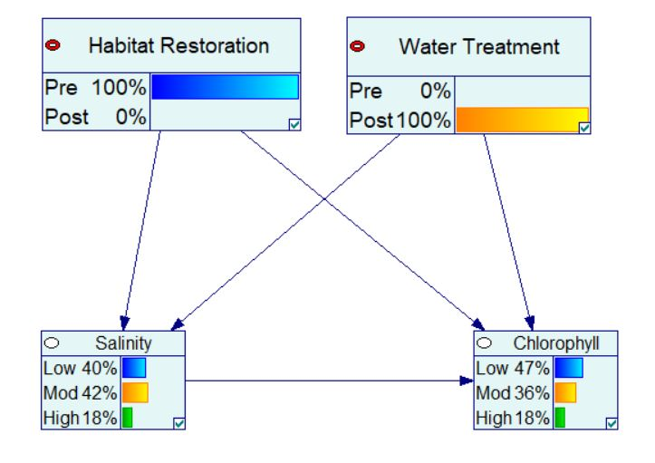

Before_HR, After_WT

```r
#Create marginal probability tables manually
cptHR <- matrix(c(0, 1), ncol = 2, dimnames = list(NULL, c("PRE", "POST")))
cptWT <- matrix(c(1, 0), ncol = 2, dimnames = list(NULL, c("PRE", "POST")))
cptSal <- (c(0.533, 0.289, 0.178, 0.667, 0.155, 0.178, 0.4, 0.422, 0.178, 0.533, 0.289, 0.178))
dim(cptSal) <- c(3, 2, 2)
dimnames(cptSal) <- list("Sal" = c("LOW", "MOD", "HIGH"), "HR" =  c("PRE", "POST"), "WT" = c("PRE", "POST"))
cptChl <- (c(0.542, 0.25, 0.208, 0.308, 0.538, 0.154, 0.286, 0, 0.714, 0.633, 0.267, 0.1, 0.429, 0.142, 0.429, 0.286, 0.428, 0.286, 0.444, 0.389, 0.167, 0.526, 0.316, 0.158, 0.375, 0.375, 0.25, 0.708, 0.25, 0.042, 0.231, 0.692, 0.077, 0.25, 0.375, 0.375))
dim(cptChl) <- c(3, 3, 2, 2)
dimnames(cptChl) <- list("Chl" = c("LOW", "MOD", "HIGH"), "Sal" = c("LOW", "MOD", "HIGH"), "HR" =  c("PRE", "POST"), "WT" = c("PRE", "POST"))
##Create Network
net = model2network("[HR][WT][Sal|HR:WT][Chl|HR:WT:Sal]")
plot(net)
```

```r
##Assign CPTs to Network
dfit = custom.fit(net, dist = list(HR = cptHR, WT = cptWT, Sal = cptSal, Chl = cptChl))
dfit
```

```
##
##   Bayesian network parameters
##
##   Parameters of node Chl (multinomial distribution)
##
## Conditional probability table:
##
## , , Sal = LOW, WT = PRE
##
##       HR
## Chl      PRE  POST
##   LOW  0.542 0.633
##   MOD  0.250 0.267
##   HIGH 0.208 0.100
##
## , , Sal = MOD, WT = PRE
##
##       HR
## Chl      PRE  POST
##   LOW  0.308 0.429
##   MOD  0.538 0.142
##   HIGH 0.154 0.429
##
## , , Sal = HIGH, WT = PRE
##
##       HR
## Chl      PRE  POST
##   LOW  0.286 0.286
##   MOD  0.000 0.428
##   HIGH 0.714 0.286
##
## , , Sal = LOW, WT = POST
##
##       HR
## Chl      PRE  POST
##   LOW  0.444 0.708
##   MOD  0.389 0.250
##   HIGH 0.167 0.042
##
## , , Sal = MOD, WT = POST
```

[output cut: 35 more lines]

```
## , , WT = POST
##
##       HR
## Sal      PRE  POST
##   LOW  0.400 0.533
##   MOD  0.422 0.289
##   HIGH 0.178 0.178
##
##
##   Parameters of node WT (multinomial distribution)
##
## Conditional probability table:
##
##  PRE POST
##    1    0
```

```r
cpquery(dfit, event = (Chl=="LOW"), evidence= (HR=="POST" & WT=="PRE"))
```

```
## [1] 0.5458
```

```r
cpquery(dfit, event = (Chl=="MOD"), evidence= (HR=="POST" & WT=="PRE"))
```

```
## [1] 0.2731
```

```r
cpquery(dfit, event = (Chl=="HIGH"), evidence= (HR=="POST" & WT=="PRE"))
```

```
## [1] 0.1829
```

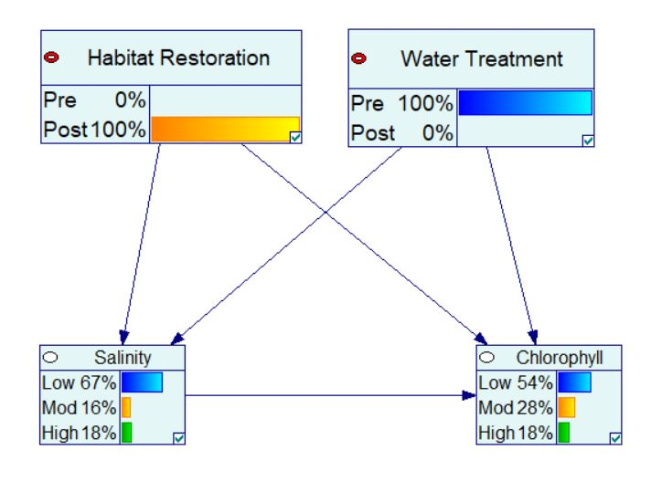

After_HR, Before_WT

```r
#cpquery(dfit, event = (Chl=="LOW"), evidence= (HR=="PRE" & WT=="PRE"))
#cpquery(dfit, event = (Chl=="MOD"), evidence= (HR=="PRE" & WT=="PRE"))
#cpquery(dfit, event = (Chl=="HIGH"), evidence= (HR=="PRE" & WT=="PRE"))
```

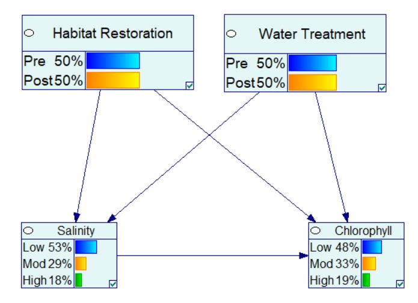

HalfWay_HR, HalfWay_WT